# What is happening in Auckland cafes?

Insights into level of activity and suburbs of cafes

```r
knitr::opts_chunk$set(echo=FALSE, message=FALSE, warning=FALSE, error=FALSE)
```

## Visual story

This visual story will explore the cafe drink orders I observed people making while I frequented some cafes in Auckland.

## Which day of the week was the busiest for cafes?

The days I captured data was mostly on weekends: Saturday and Sunday, and some data on Monday. From this Saturday can generally be said to have the highest activity.

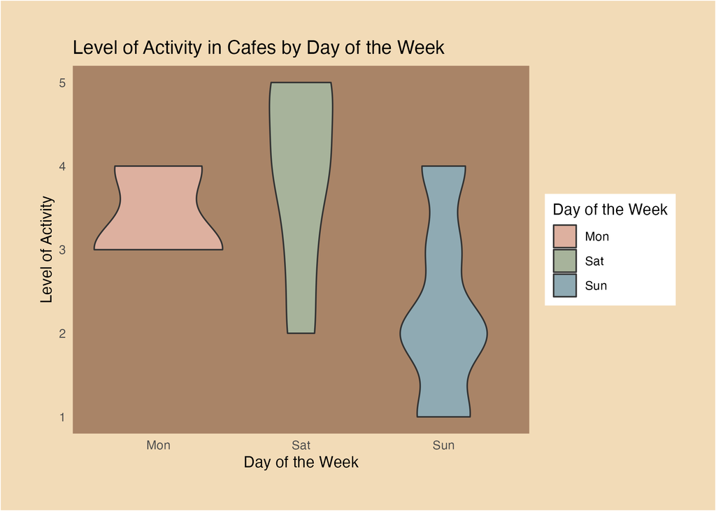

## Which hours of the day are cafes busiest?

Naturally we wonder then what time of day is there lots of orders coming in for cafes. From the cafes I went to there was the highest activity and orders coming in at 9am-10am. However, the limitation is that I did not wake up early enough to see how busy it was before 9am.

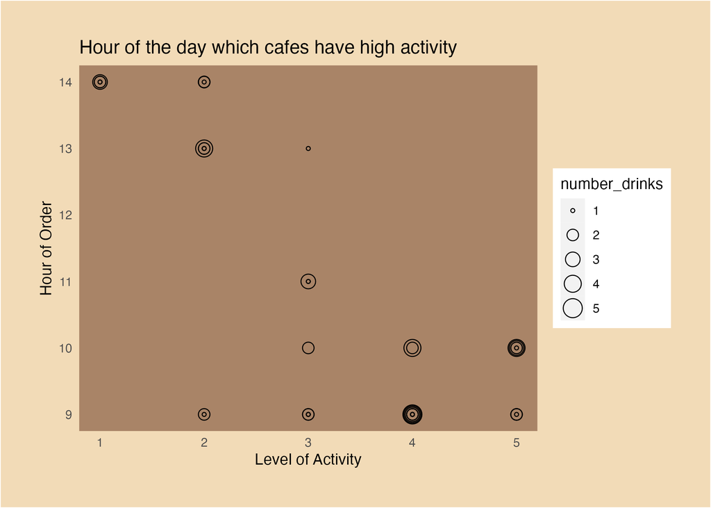

## Which time of day are cafe drinks ordered in certain surburbs?

There is a deficiency in the data as the time of day depended on what time of day I visited the cafes in certain areas of Auckland. But it seems Auckland City Central has a fairly even mix of orders in the morning and afternoon.

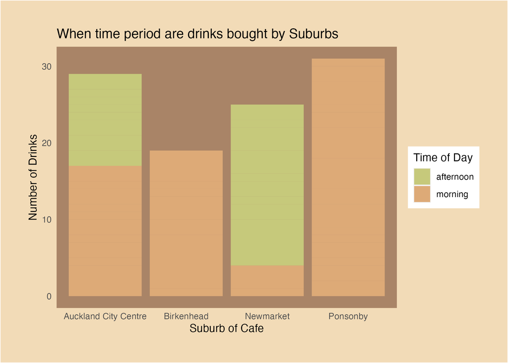

## Does preference of drinks depend on the surburb?

The data is from cafes so we would expect drinks to have caffeine (because most orders would be of coffee). Birkenhead and Ponsonby are areas where there is a higher amount of non-caffeine drinks ordered.

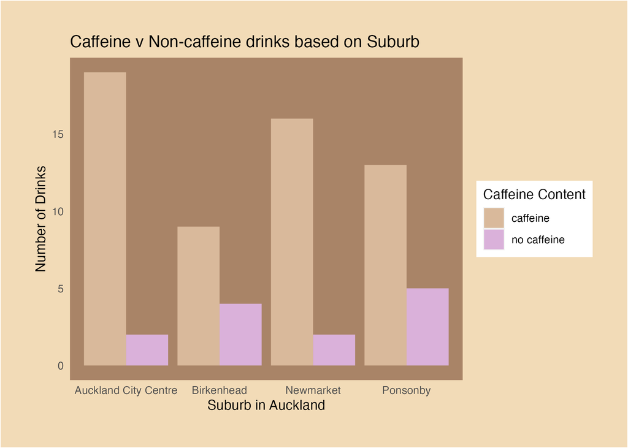